# Sentimental Analysis: Twitter’s Feelings on Chronological Order

This is a sentimental analysis using tweets from Twitter. I wanted to see how users felt about how social media feed nowadays having been optimized by an algorithm instead of in chronological order.

A few things need to be noted before continuing:

- The tweets are from August 26, 2018-August 31, 2018 and September 3, 2018-September 5, 2018
- I was only able to receive a max of 564 tweets from the API (218 without including retweets)

If you want to see the code, visit the Github repo [here](https://github.com/kchaaa/sentimental-analysis-feed).

# Set Up

To set up, you need to install the following libraries:

```r
# General Purpose (dplyr, tidyr, ggplot2, stringr, readr, purr, tibble, forcats)
library(tidyverse)

# Sentimental Analysis
library(tidytext)

# Access Twitter
library(twitteR)
```

# Accessing Twitter

In order to receive tweets, you need to sign up for a developer account [here](https://developer.twitter.com/en/apps). From there, you can access the consumer keys and access token:

```r
# Consumer and Access keys
consumer_key <- "consumer key"
consumer_secret <- "secret consumer key"
access_token <- "access token"
access_secret <- "secret access token"

# Authenticate
# setup_twitter_oauth(consumer_key, consumer_secret, access_token, access_secret)
```

Now that the app is authorized to access twitter, I will retrieve some tweets related to the key word: “**chronological feed**. I won’t be including retweets because I fear the data will be clouded with duplicates from the retweets.

```r
# # Search Twitter for tweets related to 'chronological feed' for the last year
# tweets <- twitteR::searchTwitter('chronological feed', n = 1800, lang ='en', since = '2018-08-24', until = '2018-09-01')
# # Strip Retweets
# tweets <- strip_retweets(tweets, strip_manual = TRUE, strip_mt = TRUE)
# # Convert to Data Frame
# df <- twListToDF(tweets)
# # Search Twitter for tweets related to 'chronological feed' for the last year
# tweets_2 <- twitteR::searchTwitter('chronological feed', n = 1800, lang ='en', since = '2018-08-08', until = '2018-09-16')
# # Strip Retweets
# tweets_2 <- strip_retweets(tweets_2, strip_manual = TRUE, strip_mt = TRUE)
# # Convert to Data Frame
# df_2 <- twListToDF(tweets_2)
#
# # Combine the data frames
# df_3 <- full_join(df, df_2)
```

Now I will save the tweets locally, so I don’t hav-e to access the API every time and keep the same tweets as I originally downloaded.

```r
# Extract the data frame save it locally
# saveRDS(df, file='tweets.rds')
# saveRDS(df_2, file='tweets_2.rds')
# saveRDS(df_3, file='tweets_3.rds') # combination of df + df_2
```

```r
# Read in the locally saved data frame that will be used from now on
data <- readRDS('tweets_3.rds')
```

# Cleaning Tweets

### Cleaning

```r
# Glimpse at first few rows
head(data$text, 6)
```

```
## [1] "@pandemona I think there's 1 feature people want out of twitter: a reverse chronological feed of tweets. This shoul https://t.co/loZOYmOoGW"
## [2] "When Twitter tries to algorithmically place perspective/conversation in your feed. \n\n1 day vs. 24m - I would love a https://t.co/1lcyEG1o8Q"
## [3] "@markspens Understood. We'll play by the same rules as the all other social media. Just curious, is Twitter still c https://t.co/SYkTjDgqkk"
## [4] "Hey @Twitter can you stop showing me 24 hour old tweets especially that involve a sporting game, I don't need to se https://t.co/a38xrgvhfp"
## [5] "Ahem, why isn't my twitter feed not chronological, this is really irritating me"
## [6] "@Twitter why cant I just get to read my Twitter feed in chronological order????  I hate your new algorithm that de https://t.co/asqzumPACi"
```

Looking at these tweets, it needs to be cleaned up for analysis. I will start by selecting the text columns only from the data frame.

```r
data1 <- data %>% select(text)
```

The first step of cleaning up these tweets is by getting rid of: * http and https links * the “@” symbol (addressing specific users) * the “#” symbol (addressing the topic) * non-english characters

This is because when I do a word-by-word analysis, I don’t want to analyze these links and symbols which won’t yield any significant results.

```r
# Get rid of links
data1$clean_text <- gsub("http.*", "", data1$text)
data1$clean_text <- gsub("https.*", "", data1$clean_text)
# Get rid of '@' and '#'
data1$clean_text <- gsub("@", "", data1$clean_text)
data1$clean_text <- gsub("#", "", data1$clean_text)
# Get rid of non-english characters
data1$clean_text <- gsub("[^\x01-\x7F]", "", data1$clean_text)
```

The library *tidytext* includes a nice function to finish up cleaning the tweets. The function, *unnest_tokens()* will: * Convert text to lowercase * Remove punctuation * Add a Unique ID for each tweet

```r
data1_clean <- data1 %>%
  dplyr::select(clean_text) %>%
  unnest_tokens(word, clean_text)
```

This is what it looks like now:

```r
head(data1_clean, 15)
```

```
##               word
## 1        pandemona
## 1.1              i
## 1.2          think
## 1.3        there's
## 1.4              1
## 1.5        feature
## 1.6         people
## 1.7           want
## 1.8            out
## 1.9             of
## 1.10       twitter
## 1.11             a
## 1.12       reverse
## 1.13 chronological
## 1.14          feed
```

### Dealing with Stop Words

Here is what the top 15 most frequent words look like:

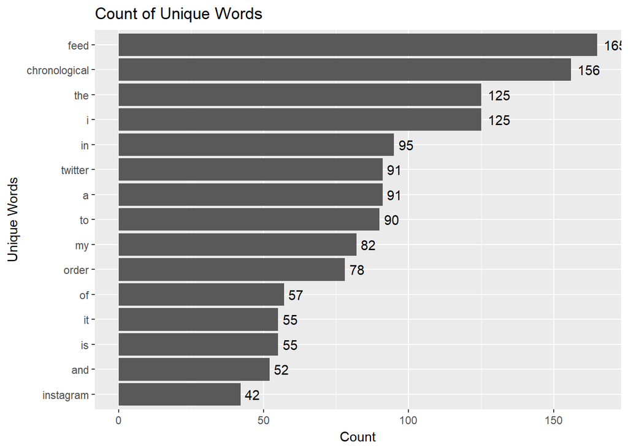

```r
# Plot Top 15 Words ----
data1_clean %>%
  count(word, sort=TRUE) %>%
  top_n(15) %>%
  mutate(word=reorder(word, n)) %>%
  ggplot(aes(x=word, y=n)) +
  geom_text(aes(label=n), position=position_dodge(width=0.9), hjust=-0.3) +
  geom_col() +
  xlab(NULL) +
  coord_flip() +
    labs(y="Count",
         x="Unique Words",
         title="Count of Unique Words")
```

The problem with this is that it includes a lot of “stop words”. Stop words are like “the”, “a”, “is”, etc. This will affect the overall count of variables and the sentimental analysis. I will now remove the stop words.

```r
# Get Rid of Stop Words ----
data("stop_words")

cleaned_tweet_words <- data1_clean %>%
                          anti_join(stop_words)
```

Now let’s see what the top 15 most frequent words look like without the stop words:

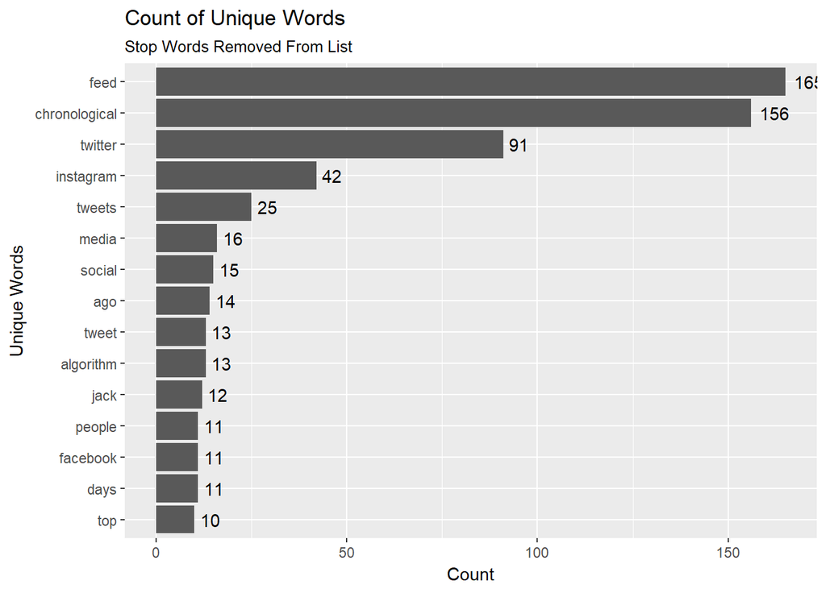

```r
# Plot Top 15 Words ----
cleaned_tweet_words %>%
  count(word, sort=TRUE) %>%
  top_n(15) %>%
  mutate(word=reorder(word, n)) %>%
  ggplot(aes(x=word, y=n)) +
  geom_text(aes(label=n), position=position_dodge(width=0.9), hjust=-0.3) +
  geom_col() +
  xlab(NULL) +
  coord_flip() +
    labs(y="Count",
         x="Unique Words",
         title="Count of Unique Words",
         subtitle="Stop Words Removed From List")
```

You will notice a lot of people talk about “chronological” and “feed” which is to be expected due to them being the key search terms. The terms that stand out to me are the ones related to social media: * twitter * instagram * media * social * jack (CEO of Twitter) * facebook

This shows people are talking about how their experience using social media are affected by the order they receive the posts in.

# Sentimental Analysis

### Overview: tidytext

In this text mining library for R, there are 3 general-purpose lexicons: * **AFINN** from Finn Årup Nielsen, * Assigns the words with a score between -5 and 5 (positive/negative score = positive/negative sentiment respectively) * **bing** from Bing Liu and collaborators, and * Determines if the word is positive or negative in a binary fashion * **NRC** from Saif Mohammad and Peter Turney * Categorizes the words into categories of positive, negative, anger, anticipation, disgust, fear, joy, sadness, surprise, and trust

I will use each method to analyze the sentiment of each tweet

To learn more, visit the [documentation](https://www.tidytextmining.com/sentiment.html).

### Analysis

Instead of keeping the unique IDs as row names, I converted it into its own column to combine the tweets that were separated word by word into 1.

```r
# Turn Unique ID into a Column
data1_clean$tweet_index <- rownames(data1_clean)
# Combine tweet_index into 1 ex 1, 1.1, 1.2, etc => 1
data1_clean$tweet_index <- as.integer(data1_clean$tweet_index)
```

Now I will conduct the sentimental analysis using the 3 methods:

```r
# Afinn
afinn <- data1_clean %>%
  inner_join(get_sentiments("afinn")) %>%
  group_by(index=tweet_index) %>%
  summarise(sentiment=sum(score)) %>%
  mutate(method="AFINN")

# Bing and NRC (calculating sentiment)
bing_and_nrc <- bind_rows(data1_clean %>%
                            inner_join(get_sentiments("bing")) %>%
                            mutate(method="Bing et al."),
                          data1_clean %>%
                            inner_join(get_sentiments("nrc") %>%
                                         filter(sentiment %in% c("positive", "negative"))) %>%
                            mutate(method="NRC")) %>%
  count(method, index=tweet_index, sentiment) %>%
  spread(sentiment, n, fill=0) %>%
  mutate(sentiment=positive - negative)
# bing (just bing results)
bing <- bing_and_nrc %>%
          filter(method=="Bing et al.")
# NRC (just NRC results)
nrc <- bing_and_nrc %>%
          filter(method=="NRC")
```

Here are a glimpse of each method:

#### AFINN

```r
head(afinn, 10)
```

```
## # A tibble: 10 x 3
##    index sentiment method
##    <int>     <int> <chr>
##  1     1         1 AFINN
##  2     2         3 AFINN
##  3     3         1 AFINN
##  4     4        -1 AFINN
##  5     5        -3 AFINN
##  6     6        -3 AFINN
##  7     8        -4 AFINN
##  8     9        -3 AFINN
##  9    10         2 AFINN
## 10    11        -4 AFINN
```

#### bing

```r
head(bing, 10)
```

```
## # A tibble: 10 x 5
##    method      index negative positive sentiment
##    <chr>       <int>    <dbl>    <dbl>     <dbl>
##  1 Bing et al.     2        0        1         1
##  2 Bing et al.     5        1        0        -1
##  3 Bing et al.     6        1        0        -1
##  4 Bing et al.     8        1        0        -1
##  5 Bing et al.     9        1        0        -1
##  6 Bing et al.    10        0        2         2
##  7 Bing et al.    11        2        0        -2
##  8 Bing et al.    13        1        1         0
##  9 Bing et al.    17        0        1         1
## 10 Bing et al.    19        1        1         0
```

#### NRC

```r
head(nrc, 10)
```

```
## # A tibble: 10 x 5
##    method index negative positive sentiment
##    <chr>  <int>    <dbl>    <dbl>     <dbl>
##  1 NRC        1        0        1         1
##  2 NRC        2        0        1         1
##  3 NRC        5        1        0        -1
##  4 NRC        6        1        0        -1
##  5 NRC        8        1        0        -1
##  6 NRC       11        2        0        -2
##  7 NRC       13        1        0        -1
##  8 NRC       14        0        1         1
##  9 NRC       17        1        1         0
## 10 NRC       19        0        2         2
```

Here is a visual representation of the sentiment score for each method:

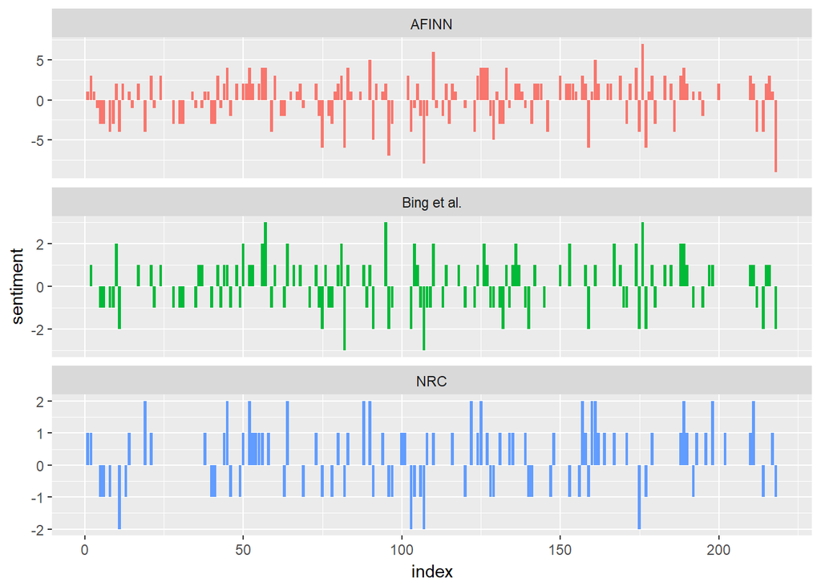

```r
# Plot Sentiment
bind_rows(afinn,
          bing_and_nrc) %>%
  ggplot(aes(index, sentiment, fill=method)) +
  geom_col(show.legend=FALSE) +
  facet_wrap(~method, ncol=1, scales="free_y")
```

It looks like there is an equal representation of positive and negative sentiments. An interesting note is that AFINN scored the words on the more extreme ends compared to the other 2 methods. Also, not all of the tweets were scored evenly among the 3 methods.

After looking at the scores of each tweet, let’s look at the sentiment scores overall.

### Exploring Count for Sentiment

I decided to include scores of 1 and -1 in the neutral category because it was close enough to a neutral feeling rather than a positive or negative sentiment.

```r
# AFINN Count
afinn_positive <- sum(afinn$sentiment > 1)
afinn_negative <- sum(afinn$sentiment < -1)
afinn_neutral <- sum(afinn$sentiment == c(0,1,-1))
# DataFrame
method <- 'AFINN'
type <- c('positive', 'negative', 'neutral')
count <- as.integer(c(afinn_positive, afinn_negative, afinn_neutral))
afinn_count <- data.frame(cbind(method, type, count), stringsAsFactors=FALSE)
afinn_count$count <- as.integer(afinn_count$count)

# NRC Count
nrc_positive <- sum(nrc$sentiment > 1)
nrc_negative <- sum(nrc$sentiment < -1)
nrc_neutral <- sum(nrc$sentiment == c(0,1,-1))
# DataFrame
method <- 'NRC'
type <- c('positive', 'negative', 'neutral')
count <- as.integer(c(nrc_positive, nrc_negative, nrc_neutral))
nrc_count <- data.frame(cbind(method, type, count), stringsAsFactors=FALSE)
nrc_count$count <- as.integer(nrc_count$count)

# Bing Count
bing_positive <- sum(bing$sentiment > 1)
bing_negative <- sum(bing$sentiment < -1)
bing_neutral <- sum(bing$sentiment == c(0,1,-1))
# DataFrame
method <- 'bing'
type <- c('positive', 'negative', 'neutral')
count <- c(bing_positive, bing_negative, bing_neutral)
bing_count <- data.frame(cbind(method, type, count), stringsAsFactors=FALSE)
bing_count$count <- as.integer(bing_count$count)
```

Here is a quick look of the sentiment count of each method:

#### AFINN

```r
afinn_count
```

```
##   method     type count
## 1  AFINN positive    66
## 2  AFINN negative    46
## 3  AFINN  neutral    16
```

#### Bing

```r
bing_count
```

```
##   method     type count
## 1   bing positive    17
## 2   bing negative    14
## 3   bing  neutral    33
```

#### NRC

```r
nrc_count
```

```
##   method     type count
## 1    NRC positive    14
## 2    NRC negative     4
## 3    NRC  neutral    37
```

Here are visual representations of the sentiment count overall:

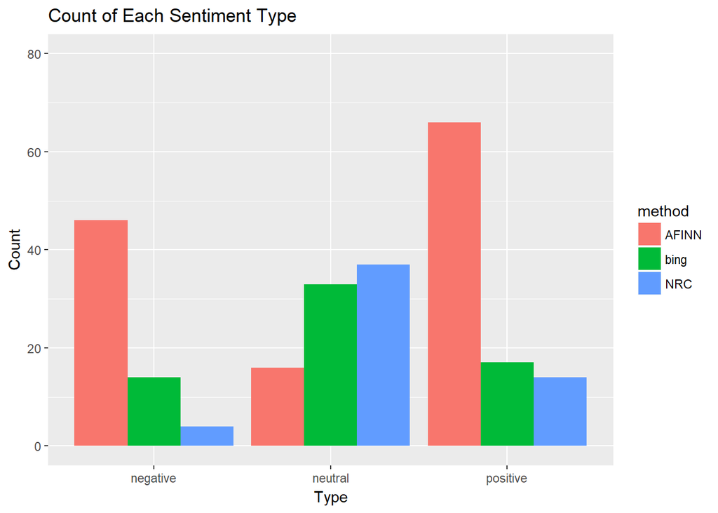

```r
# Plot: By Type
bind_rows(afinn_count, nrc_count, bing_count) %>%
ggplot(aes(x=type, y=count)) +
  geom_bar(aes(fill=method), position="dodge", stat="identity") +
  labs(y="Count",
       x="Type",
       title="Count of Each Sentiment Type") +
 ylim(0,80)
```

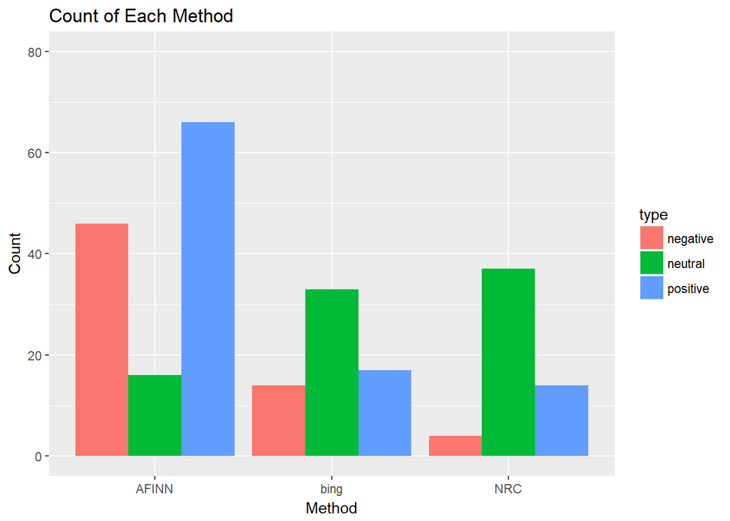

```r
# Plot: By Method
bind_rows(afinn_count, nrc_count, bing_count) %>%
  ggplot(aes(x=method, y=count)) +
  geom_bar(aes(fill=type), position="dodge", stat="identity") +
  labs(y="Count",
       x="Method",
       title="Count of Each Method") +
  ylim(0,80)
```

# Conclusion

Overall, there seems to a more positive sentiment when it comes to people talking about their social media feeds in chronological order. While this was a nice insight to know, I don’t know how true these results might be to reality. Whenever I see tweets on Twitter talking about how their social media feeds are ordered, it usually is in a negative context.

### Shortcomings

This might be a shortcoming of tidytext due to how each method scores words as positive or negative. If I were to do this again, I would have to come up with a more “sophisticated” library of words that indicate how positive or negative the words are. I think looking at this in a qualitative/business strategy context would help me understand this better.

Also, there might not have been enough information due to the lack of tweets. As mentioned earlier, I only was able to use less than 300 tweets. If Twitter’s API would let me receive more tweets from a longer period of time, then I would have been able to conduct a better analysis.